# **Supervised Learning Project Solution**

# **PART A**

DOMAIN: Medical

CONTEXT: Medical research university X is undergoing a deep research on patients with certain conditions. University has an internal AI team. Due to confidentiality the patient’s details and the conditions are masked by the client by providing different datasets to the AI team for developing a AIML model which can predict the condition of the patient depending on the received test results.

DATA DESCRIPTION: The data consists of biomechanics features of the patients according to their current conditions. Each patient is represented in the data set by six biomechanics attributes derived from the shape and orientation of the condition to their body part.

PROJECT OBJECTIVE: To Demonstrate the ability to fetch, process and leverage data to generate useful predictions by training Supervised Learning algorithms.

## **1. Data Understanding**

```python
# Import all the necessary libraries.
import pandas as pd
import numpy as np
import seaborn as sns
import matplotlib.pyplot as plt
%matplotlib inline
from scipy.stats import zscore
```

**A. Read all the 3 CSV files as DataFrame and store them into 3 separate variables.**

```python
# Import Dataset
df1 = pd.read_csv('Part1+-+Normal.csv')
df2 = pd.read_csv('Part1+-+Type_H.csv')
df3 = pd.read_csv('Part1+-+Type_S.csv')
```

**B. Print Shape and columns of all the 3 DataFrames.**

```python
print("Shape of dataframe 1 is", df1.shape)
print("\nColumn names of dataframe 1 are:", list(df1))

print("\nShape of dataframe 2 is", df2.shape)
print("\nColumn names of dataframe 2 are:", list(df2))

print("\nShape of dataframe 3 is", df3.shape)
print("\nColumn names of dataframe 3 are:", list(df3))
```

```
Shape of dataframe 1 is (100, 7)

Column names of dataframe 1 are: ['P_incidence', 'P_tilt', 'L_angle', 'S_slope', 'P_radius', 'S_Degree', 'Class']

Shape of dataframe 2 is (60, 7)

Column names of dataframe 2 are: ['P_incidence', 'P_tilt', 'L_angle', 'S_slope', 'P_radius', 'S_Degree', 'Class']

Shape of dataframe 3 is (150, 7)

Column names of dataframe 3 are: ['P_incidence', 'P_tilt', 'L_angle', 'S_slope', 'P_radius', 'S_Degree', 'Class']
```

**Observation:**

Dataframe 1 has 100 rows, 7 columns

Dataframe 2 has 60 rows, 7 columns

Dataframe 3 has 150 rows, 7 columns

**C. Compare Column names of all the 3 DataFrames and clearly write observations.**

```python
list1 = df1.columns.values.tolist()
list2 = df2.columns.values.tolist()
list3 = df3.columns.values.tolist()

if (list1 == list2 == list3):
  print("All column names are same and in same order")
else:
  print("All column names are NOT same")
```

```
All column names are same and in same order
```

**Observation:**

All three dataframes have the same column names at the same indices.

**D. Print DataTypes of all the 3 DataFrames.**

```python
print(df1.dtypes)
```

```
P_incidence    float64
P_tilt         float64
L_angle        float64
S_slope        float64
P_radius       float64
S_Degree       float64
Class           object
dtype: object
```

```python
print(df2.dtypes)
```

```
P_incidence    float64
P_tilt         float64
L_angle        float64
S_slope        float64
P_radius       float64
S_Degree       float64
Class           object
dtype: object
```

```python
print(df3.dtypes)
```

```
P_incidence    float64
P_tilt         float64
L_angle        float64
S_slope        float64
P_radius       float64
S_Degree       float64
Class           object
dtype: object
```

**Observation:**

The data type of each column is same in all three dataframes. All the columns are numerical except the "Class" column which is catagorical.

**E. Observe and share variation in ‘Class’ feature of all the 3 DataFrames.**

```python
print("Values in 'Class' Column of dataframe 1:")
print(df1['Class'].value_counts())
print("\nValues in 'Class' Column of dataframe 2:")
print(df2['Class'].value_counts())
print("\nValues in 'Class' Column of dataframe 3:")
print(df3['Class'].value_counts())
```

```
Values in 'Class' Column of dataframe 1:
Normal    73
Nrmal     27
Name: Class, dtype: int64

Values in 'Class' Column of dataframe 2:
Type_H    37
type_h    23
Name: Class, dtype: int64

Values in 'Class' Column of dataframe 3:
Type_S    133
tp_s       17
Name: Class, dtype: int64
```

**Observation:**

Different strings are used to represent the same thing in "Class" feature column:

Dataframe 1 : Normal, Nrmal

Dataframe 2 : Type_H, type_h

Dataframe 3 : Type_S, tp_s

## **2. Data Preparation and Exploration**

**A. Unify all the variations in ‘Class’ feature for all the 3 DataFrames.**

```python
df1.loc[(df1["Class"] != "normal"), "Class"] = "normal"
print("Values in 'Class' Column of dataframe 1:")
print(df1['Class'].value_counts())

df2.loc[(df2["Class"] != "type_h"), "Class"] = "type_h"
print("\nValues in 'Class' Column of dataframe 2:")
print(df2['Class'].value_counts())

df3.loc[(df3["Class"] != "type_s"), "Class"] = "type_s"
print("\nValues in 'Class' Column of dataframe 3:")
print(df3['Class'].value_counts())
```

```
Values in 'Class' Column of dataframe 1:
normal    100
Name: Class, dtype: int64

Values in 'Class' Column of dataframe 2:
type_h    60
Name: Class, dtype: int64

Values in 'Class' Column of dataframe 3:
type_s    150
Name: Class, dtype: int64
```

**Observation:**

There is only one value for each type of Class in each dataframe.

**B. Combine all the 3 DataFrames to form a single DataFrame**

```python
df = pd.concat([df1,df2,df3])
```

```python
df.reset_index(inplace= True)
```

```python
df.shape
```

```
(310, 8)
```

**C. Print 5 random samples of this DataFrame**

```python
df.sample(5)
```

|  | index | P_incidence | P_tilt | L_angle | S_slope | P_radius | S_Degree | Class |
| --- | --- | --- | --- | --- | --- | --- | --- | --- |
| 270 | 110 | 64.809541 | 15.174078 | 58.839994 | 49.635463 | 111.679961 | 21.407198 | type_s |
| 223 | 63 | 65.665347 | 10.540675 | 56.489135 | 55.124672 | 109.162777 | 53.932020 | type_s |
| 207 | 47 | 78.425951 | 33.425951 | 76.277439 | 45.000000 | 138.554111 | 77.155172 | type_s |
| 94 | 94 | 45.075450 | 12.306951 | 44.583177 | 32.768499 | 147.894637 | -8.941709 | normal |
| 17 | 17 | 61.540599 | 19.676957 | 52.892229 | 41.863642 | 118.686268 | 4.815031 | normal |

**D. Print Feature-wise percentage of Null values.**

```python
(df.isnull().sum()/len(df))*100
```

```
index          0.0
P_incidence    0.0
P_tilt         0.0
L_angle        0.0
S_slope        0.0
P_radius       0.0
S_Degree       0.0
Class          0.0
dtype: float64
```

**Observation:**

No Null Values in any of the columns

**E. Check 5-point summary of the new DataFrame.**

```python
df.describe().T
```

|  | count | mean | std | min | 25% | 50% | 75% | max |
| --- | --- | --- | --- | --- | --- | --- | --- | --- |
| index | 310.0 | 57.725806 | 39.385724 | 0.000000 | 25.250000 | 51.000000 | 85.750000 | 149.000000 |
| P_incidence | 310.0 | 60.496653 | 17.236520 | 26.147921 | 46.430294 | 58.691038 | 72.877696 | 129.834041 |
| P_tilt | 310.0 | 17.542822 | 10.008330 | -6.554948 | 10.667069 | 16.357689 | 22.120395 | 49.431864 |
| L_angle | 310.0 | 51.930930 | 18.554064 | 14.000000 | 37.000000 | 49.562398 | 63.000000 | 125.742385 |
| S_slope | 310.0 | 42.953831 | 13.423102 | 13.366931 | 33.347122 | 42.404912 | 52.695888 | 121.429566 |
| P_radius | 310.0 | 117.920655 | 13.317377 | 70.082575 | 110.709196 | 118.268178 | 125.467674 | 163.071041 |
| S_Degree | 310.0 | 26.296694 | 37.559027 | -11.058179 | 1.603727 | 11.767934 | 41.287352 | 418.543082 |

## **3. Data Analysis**

**A. Visualize a heatmap to understand correlation between all features**

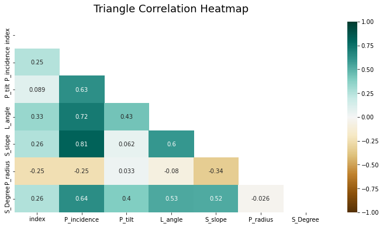

```python
plt.figure(figsize=(12, 6))
# define the mask to set the values in the upper triangle to True
mask = np.triu(np.ones_like(df.corr(), dtype = bool))
heatmap = sns.heatmap(df.corr(), mask=mask, vmin=-1, vmax=1, annot=True, cmap='BrBG')
heatmap.set_title('Triangle Correlation Heatmap', fontdict={'fontsize':18}, pad=16);
```

**B. Share insights on correlation.**

> **A. Features having stronger correlation with correlation value.**

> **B. Features having weaker correlation with correlation value.**

**Observation:**

High degree: If the coefficient value lies between ± 0.50 and ± 1, then it is said to be a strong correlation.

Moderate degree: If the value lies between ± 0.30 and ± 0.49, then it is said to be a medium correlation.

Low degree: When the value lies below ± .29, then it is said to be a small correlation.

Considering the above statements, the answers have been derived.

**A. Following has strong correlation:**

P_incidence has strong correlation with S_Slope (0.81), L_angle (0.72), S_Degree (0.64), P_tilt (0.63).

L_angle has strong correlation with S_Slope (0.6), S_Degree (0.53).

S_Slope has strong correlation with S_Degree (0.52).

**B. Following has weaker correlation:**

P_incidence -> P_radius (-0.25)

P_tilt -> P_radius (0.033)

P_tilt -> S_Slope (0.062)

L_angle -> P_radius (-0.08)

P_radius -> S_Degree (-0.026)

**C. Visualize a pairplot with 3 classes distinguished by colors and share insights.**

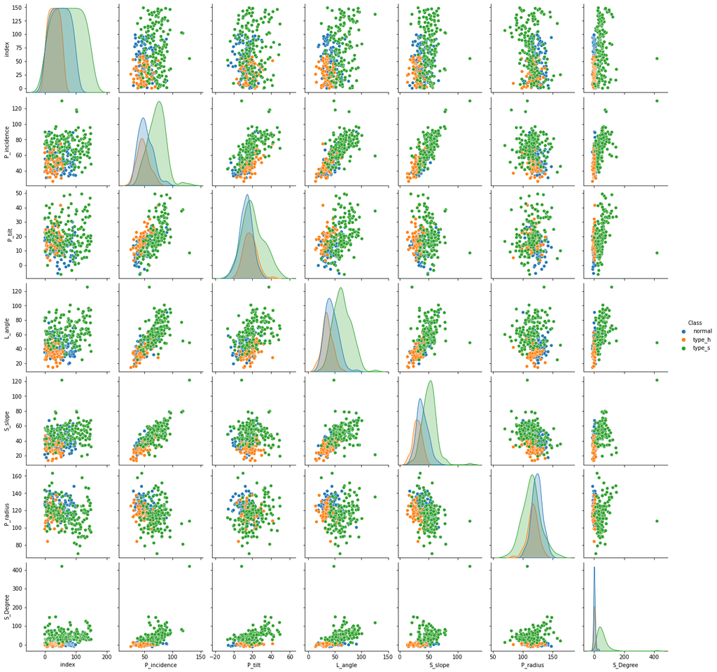

```python
sns.pairplot(df, hue = "Class")
plt.show()
```

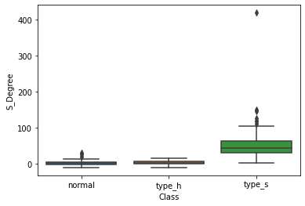

```python
sns.boxplot(y = "S_Degree", x = "Class", data = df);
```

**Observations:**

More observations are recorded for type_s class. It also has few Outliers.

P_radius has a very low correlation with other features.

For S_degree, the variation is more in type_s compared to other classes.Outlier is seen for type_s.

P_incidence has more +ve correlation with most other features except P_radius.

**D. Visualize a jointplot for ‘P_incidence’ and ‘S_slope’ and share insights.**

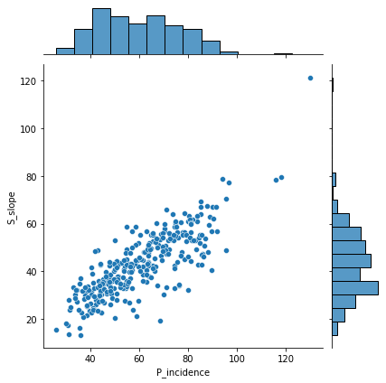

```python
sns.jointplot(x = df["P_incidence"], y = df["S_slope"]);
```

**Observation:**

High correlation observed between the two features. Few outliers can also be seen.

**E. Visualize a boxplot to check distribution of the features and share insights.**

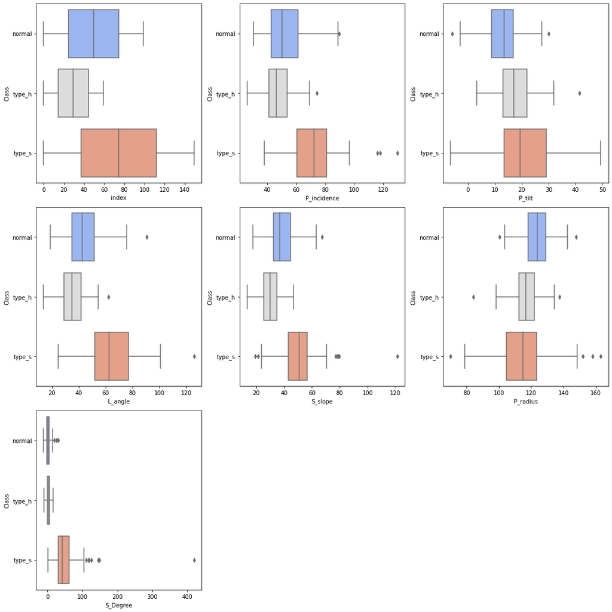

```python
n = 1
plt.figure(figsize=(15,15))
for column in df.describe().columns:
  plt.subplot(3, 3, n)
  n = n+1
  sns.boxplot(x = df[column], y = df["Class"], palette= 'coolwarm')
  plt.tight_layout()
```

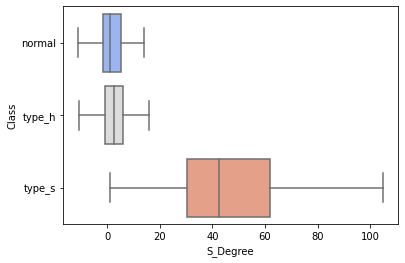

```python
# Remove outliers and check S_Degree again.
sns.boxplot(x = df["S_Degree"], y = df["Class"], palette= 'coolwarm', showfliers=False);
```

**Observation:**

1. Index Column: Type_S has more records followed by Normal and then Type_H.
2. P_incidence : Few outliers are seen in all classes. Type_s is slightly left skewed whereas normal is right skewed.
3. P_tilt : Couple of outliers seen for normal and type_h class. Almost normal distribution seen in all classes.
4. L_angle : One outlier seen in all classes. Almost normal distribution seen in all classes.
5. S_slope : Type_s is left skewed and has many outliers.
6. P_radius : Outliers seen on both extremes for all classes. Can say almost normal distribution in all classes.
7. S_Degree : One very nasty outlier seen in type_s. Without Outliers, the normal and type_h classes have almost similar observations. Type_S has large variation compared to other classes and is slightly right skewed.

## **4. Model Building**

```python
from sklearn.neighbors import KNeighborsClassifier
from sklearn.model_selection import train_test_split
from sklearn.preprocessing import StandardScaler
import os,sys
```

```python
df.info()
```

```
<class 'pandas.core.frame.DataFrame'>
RangeIndex: 310 entries, 0 to 309
Data columns (total 8 columns):
 #   Column       Non-Null Count  Dtype
---  ------       --------------  -----
 0   index        310 non-null    int64
 1   P_incidence  310 non-null    float64
 2   P_tilt       310 non-null    float64
 3   L_angle      310 non-null    float64
 4   S_slope      310 non-null    float64
 5   P_radius     310 non-null    float64
 6   S_Degree     310 non-null    float64
 7   Class        310 non-null    object
dtypes: float64(6), int64(1), object(1)
memory usage: 19.5+ KB
```

```python
#Convert X & Y variable to a categorical variable as relevant
df['Class'] = df['Class'].astype('category')
```

```python
# The first column is index column which is patient id and nothing to do with the model attriibutes. So drop it.
df = df.drop(labels = "index", axis = 1)
```

```python
df.info()
```

```
<class 'pandas.core.frame.DataFrame'>
RangeIndex: 310 entries, 0 to 309
Data columns (total 7 columns):
 #   Column       Non-Null Count  Dtype
---  ------       --------------  -----
 0   P_incidence  310 non-null    float64
 1   P_tilt       310 non-null    float64
 2   L_angle      310 non-null    float64
 3   S_slope      310 non-null    float64
 4   P_radius     310 non-null    float64
 5   S_Degree     310 non-null    float64
 6   Class        310 non-null    category
dtypes: category(1), float64(6)
memory usage: 15.1 KB
```

**A. Split data into X and Y.**

```python
# Define X and Y variables
X = df.drop('Class', axis=1)
Y = df['Class']
```

**B. Split data into train and test with 80:20 proportion.**

```python
object= StandardScaler()
Xscale = object.fit_transform(X)
```

```python
# Split into training and test set
X_train, X_test, y_train, y_test = train_test_split(Xscale, Y, test_size=0.20,random_state=42, stratify=Y)
```

**C. Train a Supervised Learning Classification base model using KNN classifier.**

```python
## Fit the model and print the scores
knn = KNeighborsClassifier()
knn.fit(X_train, y_train)
# predict the response for test data
y_test_pred = knn.predict(X_test)
# predict the response for train data
y_train_pred = knn.predict(X_train)
```

**D. Print all the possible performance metrics for both train and test data.**

```python
#import libraries
from sklearn.metrics import precision_score, recall_score, f1_score, accuracy_score
from tabulate import tabulate
```

```python
# Add necessary functions
def get_precision(a, b):
  return np.round(precision_score(a, b, average = 'macro'), 2)

def get_accuracy(a, b):
  return np.round(accuracy_score(a, b), 2)

def get_recall(a, b):
  return np.round(recall_score(a, b, average = 'macro'), 2)

def get_f1(a, b):
  return np.round(f1_score(a, b, average = 'macro'), 2)

def print_metrics():
    # Creating a list that we want to tabulate
    my_list = [
      ["Data Type", "Precision", "Recall", "Accuracy", "F1 Score"],
      ["Test",  get_precision(y_test, y_test_pred),
                get_recall(y_test, y_test_pred),
                get_accuracy(y_test, y_test_pred),
                get_f1(y_test, y_test_pred)],
      ["Train", get_precision(y_train, y_train_pred),
                get_recall(y_train, y_train_pred),
                get_accuracy(y_train, y_train_pred),
                get_f1(y_train, y_train_pred)],
    ]
    # Printing the tabulated list
    print(tabulate(my_list))
```

```python
print_metrics()
print("Precision Variance = ", abs(round((get_precision(y_test, y_test_pred) - get_precision(y_train, y_train_pred)), 2)))
print("Accuracy Variance = ",  abs(round((get_accuracy(y_test, y_test_pred)  - get_accuracy(y_train, y_train_pred)), 2)))
```

```
---------  ---------  ------  --------  --------
Data Type  Precision  Recall  Accuracy  F1 Score
Test       0.7        0.7     0.71      0.7
Train      0.82       0.82    0.85      0.82
---------  ---------  ------  --------  --------
Precision Variance =  0.12
Accuracy Variance =  0.14
```

## **5. Performance Improvement**

**A. Experiment with various parameters to improve performance of the base model.**

```python
# Build the model and train and test on training and test sets respectively using scikit-learn.

# creating odd list of K for KNN
myList = list(range(1,20))

# subsetting just the odd ones
neighbors = list(filter(lambda x: x % 2 != 0, myList))
```

```python
# Compare performance metrics for values from 1,3,5....19
p_distances = [1, 2, 3, 4, 5]
leaf = [1, 2, 3, 4, 5]

for k in neighbors:
  for p in p_distances:
    for l in leaf:
        knn2 = KNeighborsClassifier(n_neighbors=k,p = p, leaf_size = l, weights = "uniform")
        knn2.fit(X_train, y_train)
        # predict the response for test data
        y_test_pred = knn2.predict(X_test)
        # predict the response for train data
        y_train_pred = knn2.predict(X_train)
        diff = abs(round((get_accuracy(y_test, y_test_pred)  - get_accuracy(y_train, y_train_pred)), 2))
        if (get_precision(y_train, y_train_pred) != 1) and (get_precision(y_test, y_test_pred) > 0.7) and (diff <= .14):
          print("\n K = %d, p = %d, l = %d" % ( k, p,l ))
          print_metrics()
          print("Precision Variance = ", abs(round((get_precision(y_test, y_test_pred) - get_precision(y_train, y_train_pred)), 2)))
          print("Accuracy Variance = ",  abs(round((get_accuracy(y_test, y_test_pred)  - get_accuracy(y_train, y_train_pred)), 2)))
```

```
 K = 5, p = 3, l = 1
---------  ---------  ------  --------  --------
Data Type  Precision  Recall  Accuracy  F1 Score
Test       0.73       0.73    0.73      0.72
Train      0.8        0.8     0.83      0.8
---------  ---------  ------  --------  --------
Precision Variance =  0.07
Accuracy Variance =  0.1

 K = 5, p = 3, l = 2
---------  ---------  ------  --------  --------
Data Type  Precision  Recall  Accuracy  F1 Score
Test       0.73       0.73    0.73      0.72
Train      0.8        0.8     0.83      0.8
---------  ---------  ------  --------  --------
Precision Variance =  0.07
Accuracy Variance =  0.1

 K = 5, p = 3, l = 3
---------  ---------  ------  --------  --------
Data Type  Precision  Recall  Accuracy  F1 Score
Test       0.73       0.73    0.73      0.72
Train      0.8        0.8     0.83      0.8
---------  ---------  ------  --------  --------
Precision Variance =  0.07
Accuracy Variance =  0.1

 K = 5, p = 3, l = 4
---------  ---------  ------  --------  --------
Data Type  Precision  Recall  Accuracy  F1 Score
Test       0.73       0.73    0.73      0.72
Train      0.8        0.8     0.83      0.8
---------  ---------  ------  --------  --------
Precision Variance =  0.07
Accuracy Variance =  0.1

 K = 5, p = 3, l = 5
---------  ---------  ------  --------  --------
Data Type  Precision  Recall  Accuracy  F1 Score
Test       0.73       0.73    0.73      0.72
```

[output cut: 169 more lines]

```
Data Type  Precision  Recall  Accuracy  F1 Score
Test       0.72       0.66    0.69      0.67
Train      0.8        0.8     0.83      0.8
---------  ---------  ------  --------  --------
Precision Variance =  0.08
Accuracy Variance =  0.14

 K = 19, p = 3, l = 5
---------  ---------  ------  --------  --------
Data Type  Precision  Recall  Accuracy  F1 Score
Test       0.72       0.66    0.69      0.67
Train      0.8        0.8     0.83      0.8
---------  ---------  ------  --------  --------
Precision Variance =  0.08
Accuracy Variance =  0.14
```

**B. Clearly showcase improvement in performance achieved.**

```python
## Untuned model and print the scores
y_test_pred = knn.predict(X_test)
# predict the response for train data
y_train_pred = knn.predict(X_train)
Prec_Var_default = abs(round((get_precision(y_test, y_test_pred) - get_precision(y_train, y_train_pred)), 2))
Acc_Var_default  = abs(round((get_accuracy(y_test, y_test_pred)  - get_accuracy(y_train, y_train_pred)), 2))
print("\nDefault Model Performance Metrics")
print_metrics()
print("Precision Variance = ", Prec_Var_default )
print("Accuracy Variance = ", Acc_Var_default)

# K = 5 , p = 3 shows least variance for Accuracy and Precision.
knn5 = KNeighborsClassifier(n_neighbors = 5, p = 3, weights = "uniform")
knn5.fit(X_train, y_train)
y_test_pred = knn5.predict(X_test)
y_train_pred = knn5.predict(X_train)
Prec_Var_tuned = abs(round((get_precision(y_test, y_test_pred) - get_precision(y_train, y_train_pred)), 2))
Acc_Var_tuned  = abs(round((get_accuracy(y_test, y_test_pred)  - get_accuracy(y_train, y_train_pred)), 2))
print("\nModel Performance Metrics with K = 5, P = 3")
print_metrics()
print("Precision Variance = ", Prec_Var_tuned )
print("Accuracy Variance = ", Acc_Var_tuned)

Prec_Var_diff = (Prec_Var_default - Prec_Var_tuned) / Prec_Var_default * 100
Acc_Var_diff = (Acc_Var_default - Acc_Var_tuned) / Acc_Var_default * 100
print("\nVariance reduction in precision = %d " % Prec_Var_diff, end = '%')
print("\nVariance reduction in accuracy = %d " % Acc_Var_diff, end = '%')
```

```
Default Model Performance Metrics
---------  ---------  ------  --------  --------
Data Type  Precision  Recall  Accuracy  F1 Score
Test       0.7        0.7     0.71      0.7
Train      0.82       0.82    0.85      0.82
---------  ---------  ------  --------  --------
Precision Variance =  0.12
Accuracy Variance =  0.14

Model Performance Metrics with K = 5, P = 3
---------  ---------  ------  --------  --------
Data Type  Precision  Recall  Accuracy  F1 Score
Test       0.73       0.73    0.73      0.72
Train      0.8        0.8     0.83      0.8
---------  ---------  ------  --------  --------
Precision Variance =  0.07
Accuracy Variance =  0.1

Variance reduction in precision = 41 %
Variance reduction in accuracy = 28 %
```

**C. Clearly state which parameters contributed most to improve model performance.**

**Observation:**

From above result with various values like K, P, L and Weights, it can be observed that though the performance seems good but the variance between test and train data is very high. Considering the best score with least variance, K = 5 and p = 3 seems optimal value. Leaf_size did not have much of any effect. Also, when tried with weights = "distance", the variance seems very high and hence is not taken up for the above tuning.

# **PART B**

• DOMAIN : Banking, Marketing

• CONTEXT: A bank X is on a massive digital transformation for all its departments. Bank has a growing customer base whee majority of them are liability customers (depositors) vs borrowers (asset customers). The bank is interested in expanding the borrowers base rapidly to bring in more business via loan interests. A campaign that the bank ran in last quarter showed an average single digit conversion rate. Digital transformation being the core strength of the business strategy, marketing department wants to devise effective campaigns with better target marketing to increase the conversion ratio to double digit with same budget as per last campaign.

• PROJECT OBJECTIVE: Build a Machine Learning model to perform focused marketing by predicting the potential customers who will convert using the historical dataset.

## **1. Data Understanding**

```python
from google.colab import drive
drive.mount('/content/drive')

# Import all the necessary libraries.
import pandas as pd
import numpy as np
import seaborn as sns
import matplotlib.pyplot as plt
%matplotlib inline
```

**A. Read both the Datasets ‘Data1’ and ‘Data 2’ as DataFrame and store them into two separate variables.**

```python
data1 = pd.read_csv('Data1.csv')
data2 = pd.read_csv('Data2.csv')
```

**B. Print shape and Column Names and DataTypes of both the Dataframes.**

```python
print("Shape of dataframe 1 is", data1.shape)
print("Shape of dataframe 2 is", data2.shape)

print("\nColumn names of dataframe 1 are:", list(data1))
print("Column names of dataframe 2 are:", list(data2))

print("\nDataType of DataFrame1 : ")
print(data1.dtypes)
print("\nDataType of DataFrame2 : ")
print(data2.dtypes)
```

```
Shape of dataframe 1 is (5000, 8)
Shape of dataframe 2 is (5000, 7)

Column names of dataframe 1 are: ['ID', 'Age', 'CustomerSince', 'HighestSpend', 'ZipCode', 'HiddenScore', 'MonthlyAverageSpend', 'Level']
Column names of dataframe 2 are: ['ID', 'Mortgage', 'Security', 'FixedDepositAccount', 'InternetBanking', 'CreditCard', 'LoanOnCard']

DataType of DataFrame1 :
ID                       int64
Age                      int64
CustomerSince            int64
HighestSpend             int64
ZipCode                  int64
HiddenScore              int64
MonthlyAverageSpend    float64
Level                    int64
dtype: object

DataType of DataFrame2 :
ID                       int64
Mortgage                 int64
Security                 int64
FixedDepositAccount      int64
InternetBanking          int64
CreditCard               int64
LoanOnCard             float64
dtype: object
```

**Observation:**

Dataframe 1 has 5000 rows, 8 columns

Dataframe 2 has 5000 rows, 7 columns

**C. Merge both the Dataframes on ‘ID’ feature to form a single DataFrame**

```python
bankdf = pd.merge(data1, data2, on='ID')
bankdf.head()
```

|  | ID | Age | CustomerSince | HighestSpend | ZipCode | HiddenScore | MonthlyAverageSpend | Level | Mortgage | Security | FixedDepositAccount | InternetBanking | CreditCard | LoanOnCard |
| --- | --- | --- | --- | --- | --- | --- | --- | --- | --- | --- | --- | --- | --- | --- |
| 0 | 1 | 25 | 1 | 49 | 91107 | 4 | 1.6 | 1 | 0 | 1 | 0 | 0 | 0 | NaN |
| 1 | 2 | 45 | 19 | 34 | 90089 | 3 | 1.5 | 1 | 0 | 1 | 0 | 0 | 0 | NaN |
| 2 | 3 | 39 | 15 | 11 | 94720 | 1 | 1.0 | 1 | 0 | 0 | 0 | 0 | 0 | NaN |
| 3 | 4 | 35 | 9 | 100 | 94112 | 1 | 2.7 | 2 | 0 | 0 | 0 | 0 | 0 | NaN |
| 4 | 5 | 35 | 8 | 45 | 91330 | 4 | 1.0 | 2 | 0 | 0 | 0 | 0 | 1 | NaN |

```python
bankdf.shape
```

```
(5000, 14)
```

**D. Change Datatype of below features to ‘Object’**

‘CreditCard’, ‘InternetBanking’, ‘FixedDepositAccount’, ‘Security’, ‘Level’, ‘HiddenScore’.

```python
bankdf[['CreditCard', 'InternetBanking', 'FixedDepositAccount', 'Security', 'Level', 'HiddenScore']] = bankdf[['CreditCard', 'InternetBanking', 'FixedDepositAccount', 'Security', 'Level', 'HiddenScore']].astype(str)
```

```python
bankdf.info()
```

```
<class 'pandas.core.frame.DataFrame'>
Int64Index: 5000 entries, 0 to 4999
Data columns (total 14 columns):
 #   Column               Non-Null Count  Dtype
---  ------               --------------  -----
 0   ID                   5000 non-null   int64
 1   Age                  5000 non-null   int64
 2   CustomerSince        5000 non-null   int64
 3   HighestSpend         5000 non-null   int64
 4   ZipCode              5000 non-null   int64
 5   HiddenScore          5000 non-null   object
 6   MonthlyAverageSpend  5000 non-null   float64
 7   Level                5000 non-null   object
 8   Mortgage             5000 non-null   int64
 9   Security             5000 non-null   object
 10  FixedDepositAccount  5000 non-null   object
 11  InternetBanking      5000 non-null   object
 12  CreditCard           5000 non-null   object
 13  LoanOnCard           4980 non-null   float64
dtypes: float64(2), int64(6), object(6)
memory usage: 585.9+ KB
```

## **2. Data Exploration and Analysis**

**A. Visualize distribution of Target variable ‘LoanOnCard’ and clearly share insights.**

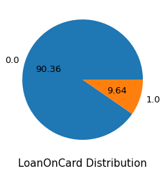

```python
#Convert LoanOnCard variable to a categorical variable as relevant
bankdf['LoanOnCard'] = bankdf['LoanOnCard'].astype('category')

plt = bankdf.groupby('LoanOnCard').size().plot(kind='pie', autopct='%.2f',  textprops={'fontsize': 13});
plt.set_xlabel('LoanOnCard Distribution', size=15);
plt.set_ylabel("");
```

```python
bankdf["LoanOnCard"].value_counts()
```

```
0.0    4500
1.0     480
Name: LoanOnCard, dtype: int64
```

**Observation:**

The target column ‘LoanOnCard’ contains only values 1s and 0s. This should be a binary column. The distribution between 0 and 1 is very uneven with number of observations of 0 nearly 90%.

**B. Check the percentage of missing values and impute if required.**

```python
print("Percentage of Missing Values:\n")
(bankdf.isnull().sum()/len(bankdf))*100
```

```
Percentage of Missing Values:
```

```
ID                     0.0
Age                    0.0
CustomerSince          0.0
HighestSpend           0.0
ZipCode                0.0
HiddenScore            0.0
MonthlyAverageSpend    0.0
Level                  0.0
Mortgage               0.0
Security               0.0
FixedDepositAccount    0.0
InternetBanking        0.0
CreditCard             0.0
LoanOnCard             0.4
dtype: float64
```

```python
# 0.4% Null values are present in the LoanOnCard column.
# Since the number of null values are very low, we will drop them.

bankdf.dropna(inplace=True)
bankdf.isna().sum()
```

```
ID                     0
Age                    0
CustomerSince          0
HighestSpend           0
ZipCode                0
HiddenScore            0
MonthlyAverageSpend    0
Level                  0
Mortgage               0
Security               0
FixedDepositAccount    0
InternetBanking        0
CreditCard             0
LoanOnCard             0
dtype: int64
```

```python
bankdf['LoanOnCard'].value_counts()
```

```
0.0    4500
1.0     480
Name: LoanOnCard, dtype: int64
```

```python
bankdf.shape
```

```
(4980, 14)
```

**C. Check for unexpected values in each categorical variable and impute with best suitable value.**

```python
bankdf.select_dtypes('object').columns
```

```
Index(['HiddenScore', 'Level', 'Security', 'FixedDepositAccount',
       'InternetBanking', 'CreditCard'],
      dtype='object')
```

```python
bankdf['HiddenScore'].value_counts()
```

```
1    1466
2    1293
4    1215
3    1006
Name: HiddenScore, dtype: int64
```

```python
bankdf['Level'].value_counts()
```

```
1    2089
3    1496
2    1395
Name: Level, dtype: int64
```

```python
bankdf['Security'].value_counts()
```

```
0    4460
1     520
Name: Security, dtype: int64
```

```python
bankdf['FixedDepositAccount'].value_counts()
```

```
0    4678
1     302
Name: FixedDepositAccount, dtype: int64
```

```python
bankdf['InternetBanking'].value_counts()
```

```
1    2974
0    2006
Name: InternetBanking, dtype: int64
```

```python
bankdf['CreditCard'].value_counts()
```

```
0    3514
1    1466
Name: CreditCard, dtype: int64
```

**Observations:**

All values seem to be valid and no unexpected values are seen in any of the categorical column.

## **3. Data Preparation and model building**

```python
from sklearn.model_selection import train_test_split
from sklearn.preprocessing import LabelEncoder
```

```python
def transform_categorical(data):
    categories = (data.dtypes =="object")
    cat_cols = list(categories[categories].index)
    label_encoder = LabelEncoder()
    for col in cat_cols:
        data[col] = label_encoder.fit_transform(data[col])
```

**A. Split data into X and Y.**

```python
bankdf.drop(['ID','ZipCode'], axis=1, inplace = True)
X = bankdf.drop('LoanOnCard',axis=1)
y = bankdf['LoanOnCard']
```

```python
transform_categorical(X)
label_encoder = LabelEncoder()
y = label_encoder.fit_transform(y)
```

```python
object= StandardScaler()
Xscale = object.fit_transform(X)
```

**B. Split data into train and test. Keep 25% data reserved for testing.**

```python
X_train, X_test, y_train, y_test = train_test_split(Xscale, y, test_size=0.25, random_state=1)
```

**C. Train a Supervised Learning Classification base model - Logistic Regression.**

```python
from sklearn.linear_model import LogisticRegression

logReg = LogisticRegression()
logReg.fit(X_train, y_train)

y_test_pred = logReg.predict(X_test)
```

**D. Print evaluation metrics for the model and clearly share insights.**

```python
from sklearn.metrics import classification_report, confusion_matrix

print(confusion_matrix(y_test,y_test_pred))
print('\nPrecision: %.3f' % precision_score(y_test, y_test_pred))
print('Recall: %.3f' % recall_score(y_test, y_test_pred))
print('F1 Score: %.3f' % f1_score(y_test, y_test_pred))
print('Accuracy: %.3f' % accuracy_score(y_test, y_test_pred))
```

```
[[1105   13]
 [  45   82]]

Precision: 0.863
Recall: 0.646
F1 Score: 0.739
Accuracy: 0.953
```

**Observation:**

The accuracy is high at 95.3% but the F1 score is low which clearly indicates imbalance in the dataset. The class 1 data is too less compared to class 0.

**E. Balance the data using the right balancing technique.**

i. Check distribution of the target variable

ii. Say output is class A : 20% and class B : 80%

iii. Here you need to balance the target variable as 50:50.

iv. Try appropriate method to achieve the same.**

```python
unique, counts = np.unique(y_train, return_counts=True)
print("Before OverSampling: \n")
print(np.asarray((unique, counts)))
```

```
Before OverSampling:

[[   0    1]
 [3382  353]]
```

```python
from imblearn.over_sampling import SMOTE
oversample = SMOTE()
X_train_balanced, y_train_balanced = oversample.fit_resample(X_train, y_train.ravel())
```

```python
unique, counts = np.unique(y_train_balanced, return_counts=True)
print("After OverSampling: \n")
print(np.asarray((unique, counts)))
```

```
After OverSampling:

[[   0    1]
 [3382 3382]]
```

**Observation:**

The training dataset is now transformed using the SMOTE and the new class distribution is summarized, showing a balanced distribution with 3382 samples in each class.

**F. Again train the same previous model on balanced data.**

```python
logRegBalanced = LogisticRegression()
logRegBalanced.fit(X_train_balanced, y_train_balanced)
y_test_pred_balanced = logRegBalanced.predict(X_test)
```

**G. Print evaluation metrics and clearly share differences observed.**

```python
print(confusion_matrix(y_test,y_test_pred_balanced))
print('\nPrecision: %.3f' % precision_score(y_test, y_test_pred_balanced))
print('Recall: %.3f' % recall_score(y_test, y_test_pred_balanced))
print('F1 Score: %.3f' % f1_score(y_test, y_test_pred_balanced))
print('Accuracy: %.3f' % accuracy_score(y_test, y_test_pred_balanced))
```

```
[[994 124]
 [ 14 113]]

Precision: 0.477
Recall: 0.890
F1 Score: 0.621
Accuracy: 0.889
```

## **4. Performance Improvement**

**A. Train a base model each for SVM, KNN.**

```python
####### SVM ###########
from sklearn.svm import SVC
svc = SVC()
svc.fit(X_train_balanced, y_train_balanced)
y_test_pred_svc = svc.predict(X_test)

print(confusion_matrix(y_test,y_test_pred_svc))
print('\nPrecision: %.3f' % precision_score(y_test, y_test_pred_svc))
print('Recall: %.3f' % recall_score(y_test, y_test_pred_svc))
print('F1 Score: %.3f' % f1_score(y_test, y_test_pred_svc))
print('Accuracy: %.3f' % accuracy_score(y_test, y_test_pred_svc))
```

```
[[1080   38]
 [   9  118]]

Precision: 0.756
Recall: 0.929
F1 Score: 0.834
Accuracy: 0.962
```

```python
########## KNN ###########
knn = KNeighborsClassifier()
knn.fit(X_train_balanced, y_train_balanced)
y_test_pred_knn = knn.predict(X_test)

print(confusion_matrix(y_test,y_test_pred_knn))
print('\nPrecision: %.3f' % precision_score(y_test, y_test_pred_knn))
print('Recall: %.3f' % recall_score(y_test, y_test_pred_knn))
print('F1 Score: %.3f' % f1_score(y_test, y_test_pred_knn))
print('Accuracy: %.3f\n' % accuracy_score(y_test, y_test_pred_knn))
```

```
[[1068   50]
 [  15  112]]

Precision: 0.691
Recall: 0.882
F1 Score: 0.775
Accuracy: 0.948
```

**B. Tune parameters for each of the models wherever required and finalize a model.**

```python
from sklearn.model_selection import GridSearchCV

############ SVC Tuning ############

# defining parameter range
param_grid = {'C': [0.1, 1, 10, 100],
              'gamma': [1, 0.1, 0.01, 0.001, 0.0001],
              'gamma':['scale', 'auto'],
              'kernel': ['linear', 'poly', 'sigmoid']}

grid = GridSearchCV(SVC(), param_grid, refit = True, verbose = 3, n_jobs=-1)

# fitting the model for grid search
grid.fit(X_train_balanced, y_train_balanced)

# print best parameter after tuning
print(grid.best_params_)
svc_grid_predictions = grid.predict(X_test)

print(confusion_matrix(y_test,svc_grid_predictions))
print('\nPrecision: %.3f' % precision_score(y_test, svc_grid_predictions))
print('Recall: %.3f' % recall_score(y_test, svc_grid_predictions))
print('F1 Score: %.3f' % f1_score(y_test, svc_grid_predictions))
print('Accuracy: %.3f' % accuracy_score(y_test, svc_grid_predictions))
```

```
Fitting 5 folds for each of 24 candidates, totalling 120 fits
{'C': 100, 'gamma': 'scale', 'kernel': 'poly'}
[[1087   31]
 [  13  114]]

Precision: 0.786
Recall: 0.898
F1 Score: 0.838
Accuracy: 0.965
```

```python
######## KNN Tuning ###################
p_distances = [1, 2]
leaf = [1, 2]
n_neighbors= [1, 3, 5]
for n in n_neighbors:
  for p in p_distances:
    for l in leaf:
        knn2 = KNeighborsClassifier(n_neighbors=n, p = p, leaf_size = l, weights = "uniform")
        knn2.fit(X_train_balanced, y_train_balanced)
        y_test_pred = knn2.predict(X_test)
        print("\nReport for K = %d, p = %d, l = %d" % (n, p, l))
        print('Precision: %.3f' % precision_score(y_test, y_test_pred))
        print('Recall: %.3f' % recall_score(y_test, y_test_pred))
        print('F1 Score: %.3f' % f1_score(y_test, y_test_pred))
        print('Accuracy: %.3f\n' % accuracy_score(y_test, y_test_pred))
```

```
Report for K = 1, p = 1, l = 1
Precision: 0.876
Recall: 0.724
F1 Score: 0.793
Accuracy: 0.961


Report for K = 1, p = 1, l = 2
Precision: 0.876
Recall: 0.724
F1 Score: 0.793
Accuracy: 0.961


Report for K = 1, p = 2, l = 1
Precision: 0.871
Recall: 0.795
F1 Score: 0.831
Accuracy: 0.967


Report for K = 1, p = 2, l = 2
Precision: 0.871
Recall: 0.795
F1 Score: 0.831
Accuracy: 0.967


Report for K = 3, p = 1, l = 1
Precision: 0.792
Recall: 0.811
F1 Score: 0.802
Accuracy: 0.959


Report for K = 3, p = 1, l = 2
Precision: 0.792
Recall: 0.811
F1 Score: 0.802
Accuracy: 0.959
```

[output cut: 27 more lines]

```
Accuracy: 0.953


Report for K = 5, p = 2, l = 1
Precision: 0.691
Recall: 0.882
F1 Score: 0.775
Accuracy: 0.948


Report for K = 5, p = 2, l = 2
Precision: 0.691
Recall: 0.882
F1 Score: 0.775
Accuracy: 0.948
```

**Observation**:

From above report, it looks like (K = 1, p = 2, l = 1, weights = uniform) has better performance. Hence considering this for final model.

**C. Print evaluation metrics for final model.**

```python
# Comparing all the above metrics, Tuned KNN metrics appears to fair well in most aspects.
# Hence selecting the KNN Tuned model as final model.

print("Untuned KNN Performance Report:\n")

print(confusion_matrix(y_test,y_test_pred_knn))
print('\nPrecision: %.3f' % precision_score(y_test, y_test_pred_knn))
print('Recall: %.3f' % recall_score(y_test, y_test_pred_knn))
print('F1 Score: %.3f' % f1_score(y_test, y_test_pred_knn))
print('Accuracy: %.3f\n' % accuracy_score(y_test, y_test_pred_knn))

knn_final = KNeighborsClassifier(leaf_size = 1, n_neighbors=1, p= 2, weights = "uniform")
knn_final.fit(X_train_balanced, y_train_balanced)
y_test_pred_knn_final = knn_final.predict(X_test)

print("\nTuned KNN Performance Report:\n")

print(confusion_matrix(y_test,y_test_pred_knn_final))
print('\nPrecision: %.3f' % precision_score(y_test, y_test_pred_knn_final))
print('Recall: %.3f' % recall_score(y_test, y_test_pred_knn_final))
print('F1 Score: %.3f' % f1_score(y_test, y_test_pred_knn_final))
print('Accuracy: %.3f' % accuracy_score(y_test, y_test_pred_knn_final))
```

```
Untuned KNN Performance Report:

[[1068   50]
 [  15  112]]

Precision: 0.691
Recall: 0.882
F1 Score: 0.775
Accuracy: 0.948


Tuned KNN Performance Report:

[[1103   15]
 [  26  101]]

Precision: 0.871
Recall: 0.795
F1 Score: 0.831
Accuracy: 0.967
```

**D. Share improvement achieved from base model to final model.**

+Precision : 26%

+F1 Score : 7.2%

+Accuracy : 2%